# AArora_Final

Ajay Arora

May 9, 2018

```r
library(RCurl)
```

```r
library(knitr)
library(ggplot2)
library(gridExtra)
library(MASS)
```

```r
sc.data <- read.csv(text = getURL("https://raw.githubusercontent.com/AjayArora35/compmath/master/train.csv"), header = T, stringsAsFactors = F)
kable(sc.data[sample(nrow(sc.data), 10), ], align='l', caption = "Sample of 10 rows", row.names=FALSE)
```

Sample of 10 rows

| Id | MSSubClass | MSZoning | LotFrontage | LotArea | Street | Alley | LotShape | LandContour | Utilities | LotConfig | LandSlope | Neighborhood | Condition1 | Condition2 | BldgType | HouseStyle | OverallQual | OverallCond | YearBuilt | YearRemodAdd | RoofStyle | RoofMatl | Exterior1st | Exterior2nd | MasVnrType | MasVnrArea | ExterQual | ExterCond | Foundation | … |
| --- | --- | --- | --- | --- | --- | --- | --- | --- | --- | --- | --- | --- | --- | --- | --- | --- | --- | --- | --- | --- | --- | --- | --- | --- | --- | --- | --- | --- | --- | --- |
| 1428 | 50 | RL | 60 | 10930 | Pave | Grvl | Reg | Bnk | AllPub | Inside | Gtl | NAmes | Artery | Norm | 1Fam | 1.5Fin | 5 | 6 | 1945 | 1950 | Gable | CompShg | MetalSd | MetalSd | None | 0 | TA | TA | CBlock | … |
| 406 | 20 | RL | NA | 9991 | Pave | NA | IR1 | Lvl | AllPub | Corner | Gtl | Sawyer | Feedr | Norm | 1Fam | 1Story | 4 | 4 | 1976 | 1993 | Gable | CompShg | Plywood | Plywood | None | 0 | TA | TA | CBlock | … |
| 424 | 60 | RL | 80 | 9200 | Pave | NA | Reg | Lvl | AllPub | Inside | Gtl | NoRidge | Norm | Norm | 1Fam | 2Story | 8 | 5 | 1998 | 1998 | Gable | CompShg | VinylSd | VinylSd | BrkFace | 473 | Gd | TA | PConc | … |
| 330 | 70 | RM | 60 | 6402 | Pave | NA | Reg | Lvl | AllPub | Corner | Gtl | IDOTRR | Norm | Norm | 1Fam | 2Story | 5 | 5 | 1920 | 1950 | Gable | CompShg | Wd Sdng | Wd Shng | None | 0 | TA | TA | PConc | … |
| 1021 | 20 | RL | 60 | 7024 | Pave | NA | Reg | Lvl | AllPub | Inside | Gtl | Edwards | Norm | Norm | 1Fam | 1Story | 4 | 5 | 2005 | 2005 | Gable | CompShg | VinylSd | VinylSd | None | 0 | TA | TA | PConc | … |
| 293 | 50 | RL | 60 | 11409 | Pave | NA | Reg | Lvl | AllPub | Inside | Gtl | Edwards | Norm | Norm | 1Fam | 1.5Fin | 5 | 4 | 1949 | 2008 | Gable | CompShg | Wd Sdng | Wd Sdng | None | 0 | TA | TA | CBlock | … |
| 526 | 20 | FV | 62 | 7500 | Pave | Pave | Reg | Lvl | AllPub | Inside | Gtl | Somerst | Norm | Norm | 1Fam | 1Story | 7 | 5 | 2005 | 2005 | Gable | CompShg | VinylSd | VinylSd | None | 0 | Gd | TA | PConc | … |
| 1177 | 20 | RL | 37 | 6951 | Pave | NA | IR1 | Lvl | AllPub | CulDSac | Gtl | Mitchel | Norm | Norm | 1Fam | 1Story | 5 | 5 | 1984 | 1985 | Gable | CompShg | HdBoard | Plywood | None | 0 | TA | TA | CBlock | … |
| 12 | 60 | RL | 85 | 11924 | Pave | NA | IR1 | Lvl | AllPub | Inside | Gtl | NridgHt | Norm | Norm | 1Fam | 2Story | 9 | 5 | 2005 | 2006 | Hip | CompShg | WdShing | Wd Shng | Stone | 286 | Ex | TA | PConc | … |
| 1246 | 80 | RL | 78 | 12090 | Pave | NA | Reg | Lvl | AllPub | Inside | Gtl | NWAmes | Norm | Norm | 1Fam | SLvl | 6 | 7 | 1984 | 2003 | Hip | CompShg | VinylSd | VinylSd | BrkFace | 74 | TA | TA | CBlock | … |

# Here’s a brief version of what you’ll find in the data description file.

```
SalePrice - the property's sale price in dollars. This is the target variable that you're trying to predict.
MSSubClass: The building class
MSZoning: The general zoning classification
LotFrontage: Linear feet of street connected to property
LotArea: Lot size in square feet
Street: Type of road access
Alley: Type of alley access
LotShape: General shape of property
LandContour: Flatness of the property
Utilities: Type of utilities available
LotConfig: Lot configuration
LandSlope: Slope of property
Neighborhood: Physical locations within Ames city limits
Condition1: Proximity to main road or railroad
Condition2: Proximity to main road or railroad (if a second is present)
BldgType: Type of dwelling
HouseStyle: Style of dwelling
OverallQual: Overall material and finish quality
OverallCond: Overall condition rating
YearBuilt: Original construction date
YearRemodAdd: Remodel date
RoofStyle: Type of roof
RoofMatl: Roof material
Exterior1st: Exterior covering on house
Exterior2nd: Exterior covering on house (if more than one material)
MasVnrType: Masonry veneer type
MasVnrArea: Masonry veneer area in square feet
ExterQual: Exterior material quality
ExterCond: Present condition of the material on the exterior
Foundation: Type of foundation
BsmtQual: Height of the basement
BsmtCond: General condition of the basement
BsmtExposure: Walkout or garden level basement walls
BsmtFinType1: Quality of basement finished area
BsmtFinSF1: Type 1 finished square feet
BsmtFinType2: Quality of second finished area (if present)
BsmtFinSF2: Type 2 finished square feet
BsmtUnfSF: Unfinished square feet of basement area
TotalBsmtSF: Total square feet of basement area
Heating: Type of heating
```

[output cut: 25 more lines]

```
PavedDrive: Paved driveway
WoodDeckSF: Wood deck area in square feet
OpenPorchSF: Open porch area in square feet
EnclosedPorch: Enclosed porch area in square feet
3SsnPorch: Three season porch area in square feet
ScreenPorch: Screen porch area in square feet
PoolArea: Pool area in square feet
PoolQC: Pool quality
Fence: Fence quality
MiscFeature: Miscellaneous feature not covered in other categories
MiscVal: $Value of miscellaneous feature
MoSold: Month Sold
YrSold: Year Sold
SaleType: Type of sale
SaleCondition: Condition of sale
```

# Choosing Variables:

1. Independent Variable: OverallQual: Overall material and finish quality
2. Dependent Variable: SalePrice - the property’s sale price in dollars. This is the target variable that you’re trying to predict.

# Y = Sales price

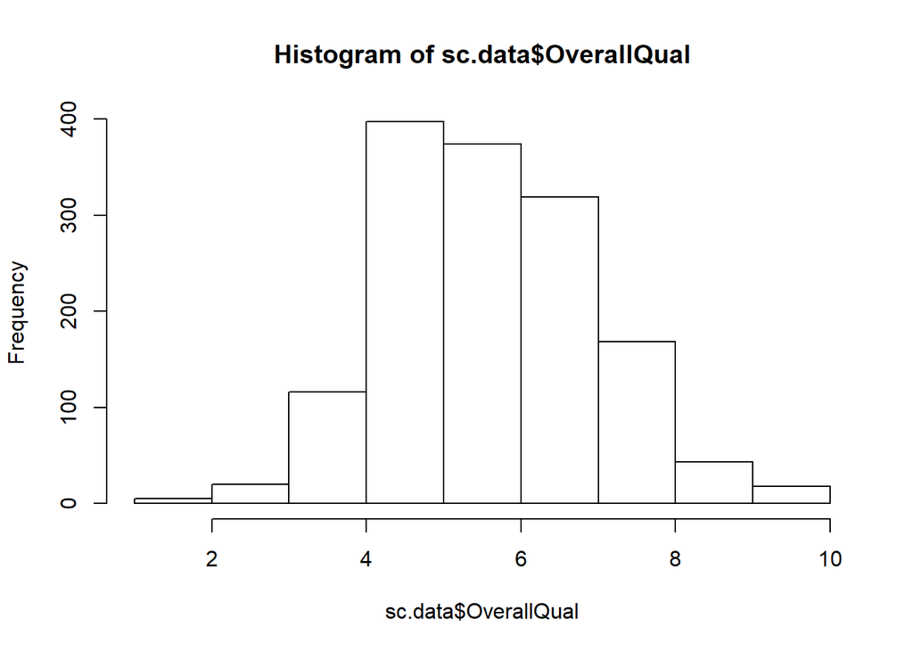

```r
hist(sc.data$OverallQual)
```

```r
# X = OverallQual
# Y = SalesPrice

X <- sc.data$OverallQual
Y <- sc.data$SalePrice
```

The chosen independent variable (OverallQual) has skewed data to the right. (A “skewed right” distribution is one in which the tail is on the right side. )

# Probability:

Definitions of Probablities:

P(X=x and Y=y) = P(x,y)

If X and Y are independent then

P(x,y) = P(x) P(y)

P(x | y) is the probability of x given y

P(x | y) = P(x,y) / P(y)  
P(x,y) = P(x | y) P(y)

If X and Y are independent then  
P(x | y) = P(x)

```r
# Summary of X (OverallQual) and Y (SalesPrice)
quantile(X)
```

```
##   0%  25%  50%  75% 100%
##    1    5    6    7   10
```

```r
summary(X)
```

```
##    Min. 1st Qu.  Median    Mean 3rd Qu.    Max.
##   1.000   5.000   6.000   6.099   7.000  10.000
```

```r
quantile(Y)
```

```
##     0%    25%    50%    75%   100%
##  34900 129975 163000 214000 755000
```

```r
summary(Y)
```

```
##    Min. 1st Qu.  Median    Mean 3rd Qu.    Max.
##   34900  129975  163000  180921  214000  755000
```

Total Rows:

```r
#Length of X (OverallQual) and Y (SalesPrice)
length(X)
```

```
## [1] 1460
```

```r
length(Y)
```

```
## [1] 1460
```

```r
x <- 5.0
y <- 129975
```

# 1st quartile of “X”: x = 5.0

# 1st quartile of “Y”: y = 129975

# a) P(X > x | Y > y)

Formula Conditional Probability (2 events): P(B|A) = P(A n B) / P(A)

P(X|Y) = P(Y n X) / P(Y)

```r
# Count of Y (SalestPrice) greater than 129975
countofY <- sum(Y > y)
countofY
```

```
## [1] 1095
```

```r
# Count of X (OverallQual > 5.0)
countofX <- sum(X > x)
countofX
```

```
## [1] 922
```

```r
# Count of both (Y > y and X > x)
countofBoth <- (sum(Y > y & X > x))
countofBoth
```

```
## [1] 848
```

```r
# Probability

(countofBoth / length(X)) / (countofY / length(Y))
```

```
## [1] 0.7744292
```

# b) P(X > x, Y > y)

```r
# Count of both (X > x and Y > y)
countofBoth2 <- sum(X > x & Y > y)
countofBoth2
```

```
## [1] 848
```

```r
# Probability

(countofBoth2 / length(X)) / (countofY / length(Y)) * (countofY / length(Y))
```

```
## [1] 0.5808219
```

# c) P(X < x | Y > y)

```r
# Count of both (X < x & Y > y)
countofBoth3 <- sum(Y > y & X < x)
countofBoth3
```

```
## [1] 23
```

```r
# Probability
countofBoth3 / length(X)
```

```
## [1] 0.01575342
```

# Count Table (Professor, I have 2 count tables – the initial question and the amended question)

sum(X <= 7 & Y <= 163000)

sum(X <= 7 & Y > 163000)

sum(X > 7 & Y <= 163000)

sum(X > 7 & Y > 163000)

[1] 728 [1] 503 [1] 4 [1] 225 Count Table

[output not shown]

```r
#Verify Count Table

table(X > 7, Y > 163000)
```

```
##
##         FALSE TRUE
##   FALSE   728  503
##   TRUE      4  225
```

```r
# Summary of X (OverallQual) and Y (SalesPrice) shown here as reference
quantile(X)
```

```
##   0%  25%  50%  75% 100%
##    1    5    6    7   10
```

```r
summary(X)
```

```
##    Min. 1st Qu.  Median    Mean 3rd Qu.    Max.
##   1.000   5.000   6.000   6.099   7.000  10.000
```

```r
quantile(Y)
```

```
##     0%    25%    50%    75%   100%
##  34900 129975 163000 214000 755000
```

```r
summary(Y)
```

```
##    Min. 1st Qu.  Median    Mean 3rd Qu.    Max.
##   34900  129975  163000  180921  214000  755000
```

sum(X <= 5 & Y <= 129975)

sum(X <= 5 & Y > 129975)

sum(X > 5 & Y <= 129975)

sum(X > 5 & Y > 129975)

[1] 291 [1] 247 [1] 74 [1] 848 Count Table

| x/y | <=1st Quartile | >1st Quartile | Total |
| --- | --- | --- | --- |
| <=1st Quartile | 291 | 247 | 538 |
| >1st Quartile | 74 | 848 | 922 |
| Total | 365 | 1095 | 1460 |

```r
#Verify Count Table

table(X > 5, Y > 129975)
```

```
##
##         FALSE TRUE
##   FALSE   291  247
##   TRUE     74  848
```

# P(AB)=P(A)P(B) ?

```r
ProbA <- sum(X > x)/length(X)
ProbA
```

```
## [1] 0.6315068
```

```r
ProbB <- sum(Y > y)/length(Y)
ProbB
```

```
## [1] 0.75
```

```r
ProbAnProbB <- ProbA * ProbB
ProbAnProbB
```

```
## [1] 0.4736301
```

P(AB)=P(B)P(A|B) Product Rule By Definition

Definitions

The conditional probability of A given B is the probability of event A, if event B

occurred. P(A|B)

A is independent of B if the conditional probability of A given B is the same as the

unconditional probability of A. P(A|B) = P(A), so we will use this test to determine

independence between variables.

```r
#P(A|B) = P(A)
#P(X>x|Y>y) = P(X>x)

#P(X>x|Y>y)
(sum(Y > y & X > x) / length(X)) / (sum(Y > y) / length(Y))
```

```
## [1] 0.7744292
```

```r
#P(X>x)
sum(X > x) / length(X)
```

```
## [1] 0.6315068
```

P(A|B) = 0.77 and P(A) = 0.63 are not equal,hence, the two variables are dependent. In addition, P(A|B) = 0.77 and ProbBnProbA = 0.47 are not equal.

# Chi-Square

The Chi Square Test, tests the hypothesis of whether the Overall Quality is independent of the Sale Price.

```r
tbl <- table(X > 5, Y > 129975)
tbl
```

```
##
##         FALSE TRUE
##   FALSE   291  247
##   TRUE     74  848
```

```r
chisq.test(tbl)
```

```
##
##  Pearson's Chi-squared test with Yates' continuity correction
##
## data:  tbl
## X-squared = 382.02, df = 1, p-value < 2.2e-16
```

NULL Hypothesis: Overall Quality has no impact on Sale price

Alternative Hypothesis: Overall Quality has an impact on Sale price

We can reject the NULL Hypothesis given the p-value (< 2.2e-16) is less than 0.05.

# Descriptive and Inferential Statistics

# Univariate Statistics

We will investigate the data for any missing values, structure, ect. We will initialize the missing data as necessary.

```r
#What is the "structure" of the data.
dim(sc.data)
```

```
## [1] 1460   81
```

```r
# Numeric types and categorical types
str(sc.data)
```

```
## 'data.frame':    1460 obs. of  81 variables:
##  $ Id           : int  1 2 3 4 5 6 7 8 9 10 ...
##  $ MSSubClass   : int  60 20 60 70 60 50 20 60 50 190 ...
##  $ MSZoning     : chr  "RL" "RL" "RL" "RL" ...
##  $ LotFrontage  : int  65 80 68 60 84 85 75 NA 51 50 ...
##  $ LotArea      : int  8450 9600 11250 9550 14260 14115 10084 10382 6120 7420 ...
##  $ Street       : chr  "Pave" "Pave" "Pave" "Pave" ...
##  $ Alley        : chr  NA NA NA NA ...
##  $ LotShape     : chr  "Reg" "Reg" "IR1" "IR1" ...
##  $ LandContour  : chr  "Lvl" "Lvl" "Lvl" "Lvl" ...
##  $ Utilities    : chr  "AllPub" "AllPub" "AllPub" "AllPub" ...
##  $ LotConfig    : chr  "Inside" "FR2" "Inside" "Corner" ...
##  $ LandSlope    : chr  "Gtl" "Gtl" "Gtl" "Gtl" ...
##  $ Neighborhood : chr  "CollgCr" "Veenker" "CollgCr" "Crawfor" ...
##  $ Condition1   : chr  "Norm" "Feedr" "Norm" "Norm" ...
```

[output cut: 67 more lines]

```r
# Summary of data
head(sc.data)
```

```
##   Id MSSubClass MSZoning LotFrontage LotArea Street Alley LotShape
## 1  1         60       RL          65    8450   Pave  <NA>      Reg
## 2  2         20       RL          80    9600   Pave  <NA>      Reg
## 3  3         60       RL          68   11250   Pave  <NA>      IR1
## 4  4         70       RL          60    9550   Pave  <NA>      IR1
## 5  5         60       RL          84   14260   Pave  <NA>      IR1
## 6  6         50       RL          85   14115   Pave  <NA>      IR1
##   LandContour Utilities LotConfig LandSlope Neighborhood Condition1
## 1         Lvl    AllPub    Inside       Gtl      CollgCr       Norm
## 2         Lvl    AllPub       FR2       Gtl      Veenker      Feedr
## 3         Lvl    AllPub    Inside       Gtl      CollgCr       Norm
## 4         Lvl    AllPub    Corner       Gtl      Crawfor       Norm
## 5         Lvl    AllPub       FR2       Gtl      NoRidge       Norm
## 6         Lvl    AllPub    Inside       Gtl      Mitchel       Norm
##   Condition2 BldgType HouseStyle OverallQual OverallCond YearBuilt
```

[output cut: 76 more lines]

```r
#Do we have missing data (add up fields with missing data)
colSums(sapply(sc.data, is.na))
```

```
##            Id    MSSubClass      MSZoning   LotFrontage       LotArea
##             0             0             0           259             0
##        Street         Alley      LotShape   LandContour     Utilities
##             0          1369             0             0             0
##     LotConfig     LandSlope  Neighborhood    Condition1    Condition2
##             0             0             0             0             0
##      BldgType    HouseStyle   OverallQual   OverallCond     YearBuilt
##             0             0             0             0             0
##  YearRemodAdd     RoofStyle      RoofMatl   Exterior1st   Exterior2nd
##             0             0             0             0             0
##    MasVnrType    MasVnrArea     ExterQual     ExterCond    Foundation
##             8             8             0             0             0
##      BsmtQual      BsmtCond  BsmtExposure  BsmtFinType1    BsmtFinSF1
##            37            37            38            37             0
##  BsmtFinType2    BsmtFinSF2     BsmtUnfSF   TotalBsmtSF       Heating
##            38             0             0             0             0
##     HeatingQC    CentralAir    Electrical     X1stFlrSF     X2ndFlrSF
##             0             0             1             0             0
##  LowQualFinSF     GrLivArea  BsmtFullBath  BsmtHalfBath      FullBath
##             0             0             0             0             0
##      HalfBath  BedroomAbvGr  KitchenAbvGr   KitchenQual  TotRmsAbvGrd
##             0             0             0             0             0
##    Functional    Fireplaces   FireplaceQu    GarageType   GarageYrBlt
##             0             0           690            81            81
##  GarageFinish    GarageCars    GarageArea    GarageQual    GarageCond
##            81             0             0            81            81
##    PavedDrive    WoodDeckSF   OpenPorchSF EnclosedPorch    X3SsnPorch
##             0             0             0             0             0
##   ScreenPorch      PoolArea        PoolQC         Fence   MiscFeature
##             0             0          1453          1179          1406
##       MiscVal        MoSold        YrSold      SaleType SaleCondition
##             0             0             0             0             0
##     SalePrice
##             0
```

```r
# What % of data is missing
sum(is.na(sc.data)) / (nrow(sc.data) * ncol(sc.data))
```

```
## [1] 0.05889565
```

```r
#Fill in missing field data with defaults and zeros

sc.data$GarageYrBlt[is.na(sc.data$GarageYrBlt)] <- sc.data$YearBuilt[is.na(sc.data$GarageYrBlt)]
sc.data$SalePrice[is.na(sc.data$SalePrice)] <- 0
sc.data$LotFrontage[is.na(sc.data$LotFrontage)] <- 0
sc.data$MasVnrArea[is.na(sc.data$MasVnrArea)] <- 0
sc.data$BsmtFullBath[is.na(sc.data$BsmtFullBath)] <- 0
sc.data$BsmtHalfBath[is.na(sc.data$BsmtHalfBath)] <- 0
sc.data$BsmtFinSF1[is.na(sc.data$BsmtFinSF1)] <- 0
sc.data$BsmtFinSF2[is.na(sc.data$BsmtFinSF2)] <- 0
sc.data$BsmtUnfSF[is.na(sc.data$BsmtUnfSF)] <- 0
sc.data$TotalBsmtSF[is.na(sc.data$TotalBsmtSF)] <- 0
sc.data$GarageCars[is.na(sc.data$GarageCars)] <- 0
sc.data$GarageArea[is.na(sc.data$GarageArea)] <- 0
sc.data[is.na(sc.data)] <- 0
```

```r
# What % of data is still missing
sum(is.na(sc.data)) / (nrow(sc.data) * ncol(sc.data))
```

```
## [1] 0
```

```r
# Summary of all the numeric variables
sc.data2 <- sc.data[, sapply(sc.data, is.numeric)]
length(sc.data2)
```

```
## [1] 38
```

```r
summary(sc.data2)
```

```
##        Id           MSSubClass     LotFrontage        LotArea
##  Min.   :   1.0   Min.   : 20.0   Min.   :  0.00   Min.   :  1300
##  1st Qu.: 365.8   1st Qu.: 20.0   1st Qu.: 42.00   1st Qu.:  7554
##  Median : 730.5   Median : 50.0   Median : 63.00   Median :  9478
##  Mean   : 730.5   Mean   : 56.9   Mean   : 57.62   Mean   : 10517
##  3rd Qu.:1095.2   3rd Qu.: 70.0   3rd Qu.: 79.00   3rd Qu.: 11602
##  Max.   :1460.0   Max.   :190.0   Max.   :313.00   Max.   :215245
##   OverallQual      OverallCond      YearBuilt     YearRemodAdd
##  Min.   : 1.000   Min.   :1.000   Min.   :1872   Min.   :1950
##  1st Qu.: 5.000   1st Qu.:5.000   1st Qu.:1954   1st Qu.:1967
##  Median : 6.000   Median :5.000   Median :1973   Median :1994
##  Mean   : 6.099   Mean   :5.575   Mean   :1971   Mean   :1985
##  3rd Qu.: 7.000   3rd Qu.:6.000   3rd Qu.:2000   3rd Qu.:2004
##  Max.   :10.000   Max.   :9.000   Max.   :2010   Max.   :2010
##    MasVnrArea       BsmtFinSF1       BsmtFinSF2        BsmtUnfSF
##  Min.   :   0.0   Min.   :   0.0   Min.   :   0.00   Min.   :   0.0
##  1st Qu.:   0.0   1st Qu.:   0.0   1st Qu.:   0.00   1st Qu.: 223.0
##  Median :   0.0   Median : 383.5   Median :   0.00   Median : 477.5
##  Mean   : 103.1   Mean   : 443.6   Mean   :  46.55   Mean   : 567.2
##  3rd Qu.: 164.2   3rd Qu.: 712.2   3rd Qu.:   0.00   3rd Qu.: 808.0
##  Max.   :1600.0   Max.   :5644.0   Max.   :1474.00   Max.   :2336.0
##   TotalBsmtSF       X1stFlrSF      X2ndFlrSF     LowQualFinSF
##  Min.   :   0.0   Min.   : 334   Min.   :   0   Min.   :  0.000
##  1st Qu.: 795.8   1st Qu.: 882   1st Qu.:   0   1st Qu.:  0.000
##  Median : 991.5   Median :1087   Median :   0   Median :  0.000
##  Mean   :1057.4   Mean   :1163   Mean   : 347   Mean   :  5.845
##  3rd Qu.:1298.2   3rd Qu.:1391   3rd Qu.: 728   3rd Qu.:  0.000
##  Max.   :6110.0   Max.   :4692   Max.   :2065   Max.   :572.000
##    GrLivArea     BsmtFullBath     BsmtHalfBath        FullBath
##  Min.   : 334   Min.   :0.0000   Min.   :0.00000   Min.   :0.000
##  1st Qu.:1130   1st Qu.:0.0000   1st Qu.:0.00000   1st Qu.:1.000
##  Median :1464   Median :0.0000   Median :0.00000   Median :2.000
##  Mean   :1515   Mean   :0.4253   Mean   :0.05753   Mean   :1.565
##  3rd Qu.:1777   3rd Qu.:1.0000   3rd Qu.:0.00000   3rd Qu.:2.000
##  Max.   :5642   Max.   :3.0000   Max.   :2.00000   Max.   :3.000
##     HalfBath       BedroomAbvGr    KitchenAbvGr    TotRmsAbvGrd
##  Min.   :0.0000   Min.   :0.000   Min.   :0.000   Min.   : 2.000
##  1st Qu.:0.0000   1st Qu.:2.000   1st Qu.:1.000   1st Qu.: 5.000
##  Median :0.0000   Median :3.000   Median :1.000   Median : 6.000
##  Mean   :0.3829   Mean   :2.866   Mean   :1.047   Mean   : 6.518
```

[output cut: 15 more lines]

```
##  Max.   :857.00   Max.   :547.00   Max.   :552.00   Max.   :508.00
##   ScreenPorch        PoolArea          MiscVal             MoSold
##  Min.   :  0.00   Min.   :  0.000   Min.   :    0.00   Min.   : 1.000
##  1st Qu.:  0.00   1st Qu.:  0.000   1st Qu.:    0.00   1st Qu.: 5.000
##  Median :  0.00   Median :  0.000   Median :    0.00   Median : 6.000
##  Mean   : 15.06   Mean   :  2.759   Mean   :   43.49   Mean   : 6.322
##  3rd Qu.:  0.00   3rd Qu.:  0.000   3rd Qu.:    0.00   3rd Qu.: 8.000
##  Max.   :480.00   Max.   :738.000   Max.   :15500.00   Max.   :12.000
##      YrSold       SalePrice
##  Min.   :2006   Min.   : 34900
##  1st Qu.:2007   1st Qu.:129975
##  Median :2008   Median :163000
##  Mean   :2008   Mean   :180921
##  3rd Qu.:2009   3rd Qu.:214000
##  Max.   :2010   Max.   :755000
```

The following density and histograms graphs depict skewness.  
MSSubClass: The building class LotFrontage: Linear feet of street connected to property LotArea: Lot size in square feet OverallQual: Overall material and finish quality

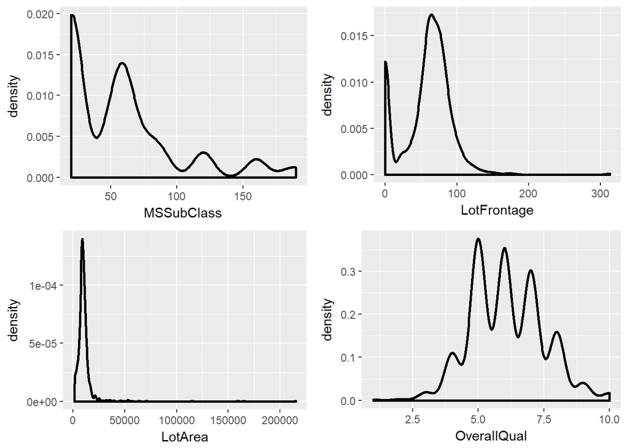

```r
# Sample Plots
graphs_list <- list()

#for(index in 2:4){

graphs_list[[1]] <- ggplot(data = sc.data2) + geom_density(aes(x = sc.data2[[2]]),   size = 1, alpha = 1.0) + xlab(paste0((colnames(sc.data2)[2]) ))

graphs_list[[2]] <- ggplot(data = sc.data2) + geom_density(aes(x = sc.data2[[3]]),   size = 1, alpha = 1.0) + xlab(paste0((colnames(sc.data2)[3]) ))

graphs_list[[3]] <- ggplot(data = sc.data2) + geom_density(aes(x = sc.data2[[4]]),   size = 1, alpha = 1.0) + xlab(paste0((colnames(sc.data2)[4]) ))

graphs_list[[4]] <- ggplot(data = sc.data2) + geom_density(aes(x = sc.data2[[5]]),   size = 1, alpha = 1.0) + xlab(paste0((colnames(sc.data2)[5]) ))
#}

do.call("grid.arrange", c(graphs_list, ncol=2))
```

[figure not shown]

```r
#Sample Histograms

graphs_list[[1]] <- ggplot(data = sc.data2) + aes(x = factor(sc.data2[[2]])) + stat_count() + xlab(colnames(sc.data2)[2]) + theme(axis.text.x = element_text(angle = 90, hjust =1))

graphs_list[[2]] <- ggplot(data = sc.data2) + aes(x = factor(sc.data2[[3]])) + stat_count() + xlab(colnames(sc.data2)[3]) + theme(axis.text.x = element_text(angle = 90, hjust =1))

graphs_list[[3]] <- ggplot(data = sc.data2) + aes(x = factor(sc.data2[[4]])) + stat_count() + xlab(colnames(sc.data2)[4]) + theme(axis.text.x = element_text(angle = 90, hjust =1))

graphs_list[[4]] <- ggplot(data = sc.data2) + aes(x = factor(sc.data2[[5]])) + stat_count() + xlab(colnames(sc.data2)[5]) + theme(axis.text.x = element_text(angle = 90, hjust =1))



do.call("grid.arrange", c(graphs_list, ncol=2))
```

# Scatterplot of X and Y

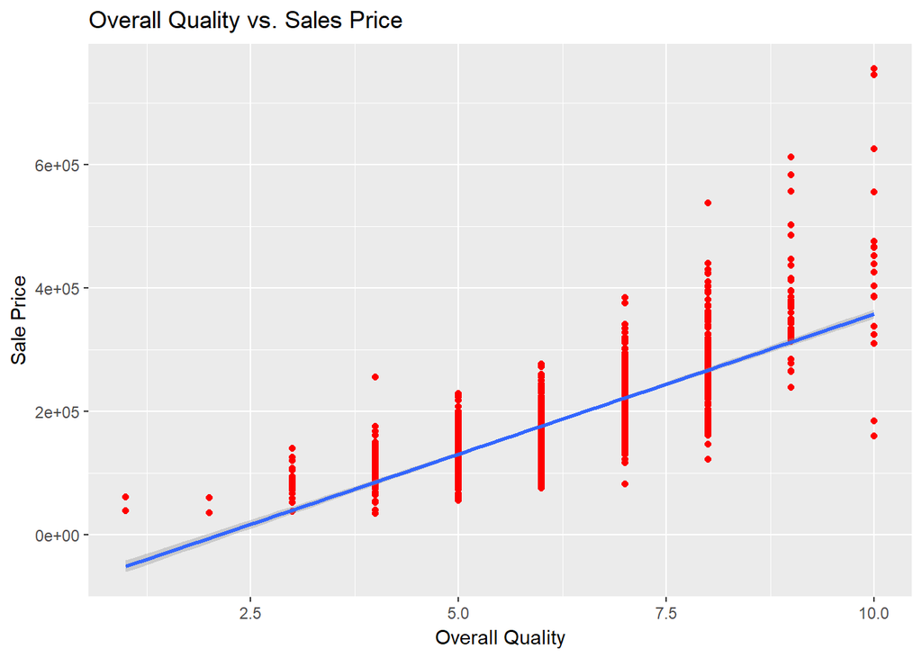

```r
ggplot(sc.data, aes(x = OverallQual, y = SalePrice)) + geom_point(color="red") + labs(x="Overall Quality", y = "Sale Price") + ggtitle("Overall Quality vs. Sales Price") + geom_smooth(method = "lm", se = TRUE)
```

# Correlation Matrix for any 3 quantitative variables in dataset.

Pearson Correlation Test:

The Pearson correlation coefficient can take a range of values from +1 to -1. A value of 0 indicates that there is no association between the two variables. A value greater than 0 indicates a positive association.

```r
# X = Overall Quality Y = Sale price Z = Year built
Z <- sc.data$YearBuilt
data <- data.frame(X, Y, Z)
cm <- cor(data)
cm
```

```
##           X         Y         Z
## X 1.0000000 0.7909816 0.5723228
## Y 0.7909816 1.0000000 0.5228973
## Z 0.5723228 0.5228973 1.0000000
```

```r
# Correlation Test for Y and X
cor.test(Y, X, conf.level = 0.92)
```

```
##
##  Pearson's product-moment correlation
##
## data:  Y and X
## t = 49.364, df = 1458, p-value < 2.2e-16
## alternative hypothesis: true correlation is not equal to 0
## 92 percent confidence interval:
##  0.7731789 0.8075387
## sample estimates:
##       cor
## 0.7909816
```

Discussion:

We see above a Pearson correlation of 0.7910 between Y and X. There exists a positive association between Sales price and Overall quality. If overall quality goes down or up, it will affect the sale price.

```r
# Correlation Test for Y and Z
cor.test(Y, Z, conf.level = 0.92)
```

```
##
##  Pearson's product-moment correlation
##
## data:  Y and Z
## t = 23.424, df = 1458, p-value < 2.2e-16
## alternative hypothesis: true correlation is not equal to 0
## 92 percent confidence interval:
##  0.4887787 0.5554189
## sample estimates:
##       cor
## 0.5228973
```

Discussion:

We see above a Pearson correlation of 0.5228973 between Y and Z. There exists a positive association between Sales price and Year built. If Year built is very old, or present date, sale price will be affected.

```r
# Correlation Test for X and Z
cor.test(X, Z, conf.level = 0.92)
```

```
##
##  Pearson's product-moment correlation
##
## data:  X and Z
## t = 26.65, df = 1458, p-value < 2.2e-16
## alternative hypothesis: true correlation is not equal to 0
## 92 percent confidence interval:
##  0.5406726 0.6023549
## sample estimates:
##       cor
## 0.5723228
```

Discussion:

T-Test Definition:

In statistics, Welch’s t-test, or unequal variances t-test, is a two-sample location test which is used to test the hypothesis that two populations have equal means.

```r
# Run the T test
t.test(Y, X, conf.level = 0.92)
```

```
##
##  Welch Two Sample t-test
##
## data:  Y and X
## t = 87.016, df = 1459, p-value < 2.2e-16
## alternative hypothesis: true difference in means is not equal to 0
## 92 percent confidence interval:
##  177272.7 184557.5
## sample estimates:
##    mean of x    mean of y
## 1.809212e+05 6.099315e+00
```

Discussion:

The T-Test shows difference in the means between Overall Quality and Sale Price. The difference in means is not equal to 0.

Definition of Familywise Error:

The familywise error rate (FWE or FWER) is the probability of a coming to at least one false conclusion in a series of hypothesis tests . In other words, it’s the probability of making at least one Type I Error. The term “familywise” error rate comes from family of tests, which is the technical definition for a series of tests on data.

A Type I error (sometimes called a Type 1 error), is the incorrect rejection of a true null hypothesis. The alpha symbol, alpha, is usually used to denote a Type I error.

Would you be worried about familywise error? Yes.

Why or why not? It is entirely possible that the first series of tests were affected by personal bias or just got lucky. Another set of tests should be done as well, with choosing the same variables and data. The second and third set of tests would be a validation step with different people performing the tests.

# Linear Algebra and Correlation

```r
#3x3 Correlation matrix from above
cm
```

```
##           X         Y         Z
## X 1.0000000 0.7909816 0.5723228
## Y 0.7909816 1.0000000 0.5228973
## Z 0.5723228 0.5228973 1.0000000
```

# Precision Matrix Detailed Steps (Rounded to 4 decimal places)

Augmented Matrix

$$A =
\begin{pmatrix}
1.0000 & 0.7909 & 0.5723 | 1 & 0 & 0\\
0.7909 & 1.0000 & 0.5228 | 0 & 1 & 0\\
0.5723 & 0.5228 & 1.0000 | 0 & 0 & 1
\end{pmatrix}$$

R2 = R2 -0.7909 x R1

$$A =
\begin{pmatrix}
1.0000 & 0.7909 & 0.5723 &| 1 & 0 & 0 \\
0 & 0.3745 & 0.0702 &| -0.7909 & 1 & 0\\
0.5723 & 0.5228 & 1.0000 &| 0 & 0 & 1
\end{pmatrix}$$

R3 = R3 -0.5723 x R1

$$A =
\begin{pmatrix}
1.0000 & 0.7909 & 0.5723 &| 1 & 0 & 0 \\
0 & 0.3745 & 0.0702 &| -0.7909 & 1 & 0\\
0 & 0.0702 & 0.6724 &| -0.5723 & 0 & 1
\end{pmatrix}$$

R3 = R3 -0.1875 x R2

$$A =
\begin{pmatrix}
1.0000 & 0.7909 & 0.5723 &| 1 & 0 & 0 \\
0 & 0.3745 & 0.0702 &| -0.7909 & 1 & 0\\
0 & 0 & 0.6592 &| -0.4239 & -0.1875 & 1
\end{pmatrix}$$

R3 = 1.5168 * R3

$$A =
\begin{pmatrix}
1.0000 & 0.7909 & 0.5723 &| 1 & 0 & 0 \\
0 & 0.3745 & 0.0702 &| -0.7909 & 1 & 0\\
0 & 0 & 1 &| -0.6431 & -0.2844 & 1.5168
\end{pmatrix}$$

R2 = R2 -0.07020 * R3

$$A =
\begin{pmatrix}
1.0000 & 0.7909 & 0.5723 &| 1 & 0 & 0 \\
0 & 0.3745 & 0 &| -0.7458 & 1.0199 & -0.1064\\
0 & 0 & 1 &| -0.6431 & -0.2844 & 1.5168
\end{pmatrix}$$

R1 = R1 -0.5723 * R3

$$A =
\begin{pmatrix}
1.0000 & 0.7909 & 0 &| 1.3680 & 0.1627 & -0.8681 \\
0 & 0.3745 & 0 &| -0.7458 & 1.0199 & -0.1064\\
0 & 0 & 1 &| -0.6431 & -0.2844 & 1.5168
\end{pmatrix}$$

R2 = 2.6713 * R2

$$A =
\begin{pmatrix}
1 & 0.7909 & 0 &| 1.3680 & 0.1627 & -0.8681 \\
0 & 1 & 0 &| -1.9923 & 2.7246 & -0.2844\\
0 & 0 & 1 &| -0.6431 & -0.2844 & 1.5168
\end{pmatrix}$$

R1 = R1 -0.7909 * R2

$$A =
\begin{pmatrix}
1 & 0 & 0 &| 2.9439 & -1.9923 & -0.6434 \\
0 & 1 & 0 &| -1.9923 & 2.7246 & -0.2844\\
0 & 0 & 1 &| -0.6431 & -0.2844 & 1.5168
\end{pmatrix}$$

$$A =
\begin{pmatrix}
2.9439 & -1.9923 & -0.6434 \\
-1.9923 & 2.7246 & -0.2844\\
-0.6431 & -0.2844 & 1.5168
\end{pmatrix}$$

# Precision matrix or inverse (verify with R)

```r
# Precision matrix (verify with R)
pm <- solve(cm)
pm
```

```
##            X          Y          Z
## X  2.9439846 -1.9923563 -0.6431116
## Y -1.9923563  2.7246511 -0.2844419
## Z -0.6431116 -0.2844419  1.5168013
```

```r
#Multiply Correlation matrix by Precision matrix
round(cm %*% pm, digits = 0)
```

```
##   X Y Z
## X 1 0 0
## Y 0 1 0
## Z 0 0 1
```

```r
#Multiply Precision matrix by Correlation matrix
round(pm %*% cm, digits = 0)
```

```
##   X Y Z
## X 1 0 0
## Y 0 1 0
## Z 0 0 1
```

```r
#Conduct LU decomposition on the matrix.

#Rounded to 4 decimal places
```

$$A =
\begin{pmatrix}
1.0000 & 0.7909 & 0.5723 \\
0.7909 & 1.0000 & 0.5228 \\
0.5723 & 0.5228 & 1.0000
\end{pmatrix}$$

Using Gaussian Elimination method

R2 = R2 - 0.079 x R1

$$A =
\begin{pmatrix}
1.0000 & 0.7909 & 0.5723 \\
0.7909 & 0.3743 & 0.0702 \\
0.5723 & 0.5228 & 1.0000
\end{pmatrix}$$

R3 = R3 - 0.5723 x R1

$$A =
\begin{pmatrix}
1.0000 & 0.7909 & 0.5723 \\
0.0000 & 0.3743 & 0.0702 \\
0.0000 & 0.0702 & 0.6724
\end{pmatrix}$$

R3 = R3 = 0.1875 x R2

$$A =
\begin{pmatrix}
1.0000 & 0.7909 & 0.5723 \\
0.0000 & 0.3743 & 0.0702 \\
0.0000 & 0.0000 & 0.6593
\end{pmatrix}$$

Let U =

$$U =
\begin{pmatrix}
1.0000 & 0.7909 & 0.5723 \\
0.0000 & 0.3743 & 0.0702 \\
0.0000 & 0.0000 & 0.6593
\end{pmatrix}$$

Hence, A = LU
$$\left[ \begin{array}{c} 1.0000 & 0.7909 & 0.5723 \\ 0.7909 & 1.0000 & 0.5228 \\ 0.5723 & 0.5228 & 1.0000 \end{array} \right] = \begin{bmatrix} 1.0000 & 0.0000 & 0.0000 \\ 0.7909 & 1.0000 & 0.0000 \\ 0.5723 & 0.1875 & 1.0000\end{bmatrix} \times \left[ \begin{array}{c} 1.0000 & 0.7909 & 0.5723 \\ 0.0000 & 0.3743 & 0.0702 \\ 0.0000 & 0.0000 & 0.6593 \end{array} \right]$$

# Calculus-Based Probability & Statistics.

```r
#Get minimun value (Since, X has a minimum value of 1, I did not shift X)
min(X)
```

```
## [1] 1
```

```r
#nonZeroMin <- min(X[X!=0])

#Shift the variable above 0

#shiftedX <- X + nonZeroMin

#Find the optimal value

lambda <- fitdistr(X, densfun = "exponential")$estimate["rate"]
lambda
```

```
##      rate
## 0.1639528
```

```r
#Take samples
exponential_distribution_of_X <- rexp(1000, lambda)
```

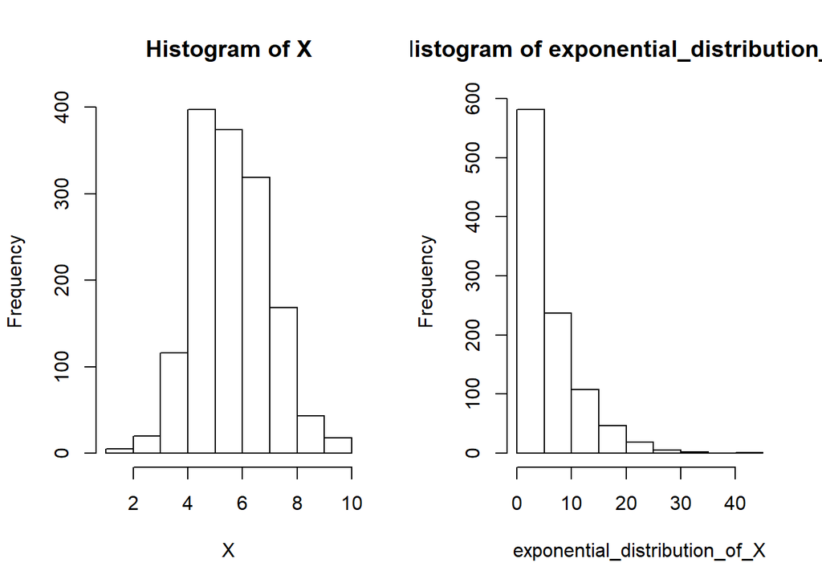

```r
par(mfrow = c(1, 2))
hist(X)
hist(exponential_distribution_of_X)
```

```r
#Percentiles
percentiles5th95th <- quantile(exponential_distribution_of_X, c(0.05,0.95))
percentiles5th95th
```

```
##         5%        95%
##  0.2181892 17.0787935
```

```r
#Formula: normal distribution we calcualte the Confidence Interval as: CI = Sample Mean plus/minus standard error.

lower_left <- mean(X) - qnorm(0.95) * sd(X) / sqrt(length(X))
lower_left
```

```
## [1] 6.03978
```

```r
upper_right <- mean(X) + qnorm(0.95) * sd(X) / sqrt(length(X))
upper_right
```

```
## [1] 6.15885
```

```r
#Provide the empirical 5th percentile and 95th
quantile(X, c(0.05, 0.95))
```

```
##  5% 95%
##   4   8
```

Definition:

Suppose p(x) is a density function for a quantity. The cumulative distribution function (cdf) for the quantity is de???ned as P(x) = integral from lower bound -infinity to upper bound x where p(t) dt. Gives: The proportion of population with value less than x The probability of having a value less than x.

https://www.quora.com/What-is-a-cumulative-distribution-function

Intuitive definition of CDF A CDF is a function that describes the probability of a random variable taking on a given value or less. A good example is rolling a single 6-sided die. Normally, we talk about the probability of a given number coming up–for example, the probability of rolling a 2 is 1 out of 6, 1/6, 0.166667. (That probability is described by the probability mass function, or PMF.) But what if you don’t just want 2; you are okay with a 2 or any number less than it? In this case, there is only one other number: 1. So now when you roll your die, you are looking for a 2 OR a 1. You are now looking for 2 outcomes out of 6, so the probability is 2/6 = 1/3. Similarly, if you want a 3 or less, the probability is 3/6 or 1/2. It’s called cumulative because you find the probability by adding up the individual probabilities of all the outcomes included. In the case of our die, when you want a 2 or less, you have 2 outcomes fulfilling this condition: 1 and 2, each with an individual probability of 1/6. 1/6 + 1/6 = 2/6 or 1/3, which is the cumulative probability of a 2. That’s what cumulative means–addition.

Discussion:

The 5th and 95th percentiles of the original data is 4 and 8 respectively.

# Modeling

```r
#Using all the variables
First_mod = lm(sc.data$SalePrice ~ ., data = sc.data)
summary(First_mod)
```

```
##
## Call:
## lm(formula = sc.data$SalePrice ~ ., data = sc.data)
##
## Residuals:
##     Min      1Q  Median      3Q     Max
## -176695   -9164       0    9498  176695
##
## Coefficients: (8 not defined because of singularities)
##                        Estimate Std. Error t value Pr(>|t|)
## (Intercept)          -2.845e+05  1.050e+06  -0.271 0.786553
## Id                    1.130e+00  1.548e+00   0.730 0.465588
## MSSubClass           -5.365e+01  8.273e+01  -0.649 0.516772
## MSZoningFV            3.261e+04  1.200e+04   2.717 0.006675 **
## MSZoningRH            2.203e+04  1.190e+04   1.851 0.064350 .
## MSZoningRL            2.486e+04  1.022e+04   2.433 0.015117 *
## MSZoningRM            2.152e+04  9.584e+03   2.246 0.024910 *
## LotFrontage           6.745e+00  2.300e+01   0.293 0.769395
## LotArea               7.230e-01  1.086e-01   6.654 4.31e-11 ***
## StreetPave            3.303e+04  1.217e+04   2.714 0.006740 **
## AlleyGrvl             1.193e+03  4.213e+03   0.283 0.777034
## AlleyPave             4.623e+02  4.737e+03   0.098 0.922276
## LotShapeIR2           4.916e+03  4.212e+03   1.167 0.243385
## LotShapeIR3           5.767e+03  8.824e+03   0.654 0.513508
## LotShapeReg           1.692e+03  1.637e+03   1.033 0.301610
## LandContourHLS        7.569e+03  5.126e+03   1.477 0.140060
## LandContourLow       -1.131e+04  6.403e+03  -1.766 0.077614 .
## LandContourLvl        5.453e+03  3.702e+03   1.473 0.140964
## UtilitiesNoSeWa      -3.643e+04  2.636e+04  -1.382 0.167114
## LotConfigCulDSac      7.803e+03  3.251e+03   2.401 0.016520 *
## LotConfigFR2         -7.945e+03  4.002e+03  -1.986 0.047312 *
## LotConfigFR3         -1.774e+04  1.255e+04  -1.413 0.157773
## LotConfigInside      -1.681e+03  1.759e+03  -0.956 0.339470
## LandSlopeMod          7.460e+03  3.971e+03   1.878 0.060567 .
## LandSlopeSev         -4.229e+04  1.138e+04  -3.716 0.000211 ***
## NeighborhoodBlueste   7.291e+03  1.921e+04   0.380 0.704337
## NeighborhoodBrDale   -2.675e+03  1.096e+04  -0.244 0.807238
## NeighborhoodBrkSide  -5.667e+03  9.468e+03  -0.599 0.549559
## NeighborhoodClearCr  -1.448e+04  9.199e+03  -1.574 0.115663
## NeighborhoodCollgCr  -1.019e+04  7.252e+03  -1.404 0.160435
```

[output cut: 224 more lines]

```
## SaleTypeCWD           1.467e+04  1.287e+04   1.140 0.254710
## SaleTypeNew           2.154e+04  1.541e+04   1.398 0.162239
## SaleTypeOth           7.591e+03  1.451e+04   0.523 0.600869
## SaleTypeWD           -4.374e+02  4.177e+03  -0.105 0.916617
## SaleConditionAdjLand  9.562e+03  1.459e+04   0.655 0.512345
## SaleConditionAlloca   1.352e+03  8.887e+03   0.152 0.879122
## SaleConditionFamily   8.849e+02  6.084e+03   0.145 0.884376
## SaleConditionNormal   6.729e+03  2.903e+03   2.318 0.020639 *
## SaleConditionPartial -4.704e+02  1.483e+04  -0.032 0.974696
## ---
## Signif. codes:  0 '***' 0.001 '**' 0.01 '*' 0.05 '.' 0.1 ' ' 1
##
## Residual standard error: 22580 on 1205 degrees of freedom
## Multiple R-squared:  0.9333, Adjusted R-squared:  0.9192
## F-statistic: 66.35 on 254 and 1205 DF,  p-value: < 2.2e-16
```

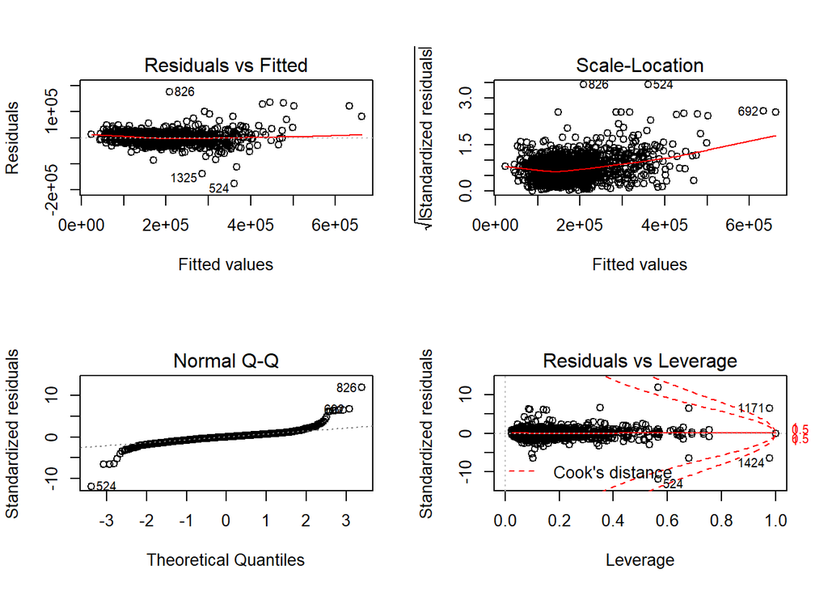

```r
#Graphical Analysis of First model
layout(matrix(c(1,2,3,4),2,2)) # optional 4 graphs/page
plot(First_mod)
```

The Residuals versus Fitted graph shows error Residuals versus fitted values. The dotted line at y = 0 indicates our fit line. Any point on the fit line has zero residual. Points above have positive residuals and points below have negative residuals.

The Scale-Location Plot graph indicates the spread of points across predicted values range. One of the assumptions for Regression is Homoscedasticity . i.e variance should be reasonably equal across the predictor range. A horizontal red line is ideal and would indicate that residuals have uniform variance across the range. As residuals spread wider from each other the red spread line goes up.

Definitions:

Influence : The Influence of an observation can be thought of in terms of how much the predicted scores would change if the observation is excluded. Cook’s Distance is a pretty good measure of influence of an observation.

Leverage : The leverage of an observation is based on how much the observation’s value on the predictor variable differs from the mean of the predictor variable. The more the leverage of an observation , the greater potential that point has in terms of influence.

The Residuals versus Levarage Plot

In this plot the dotted red lines are Cook’s distance and the areas of interest for us are the ones outside dotted line on top right corner or bottom right corner. If any point falls in that region , we say that the observation has high leverage or potential for influencing our model is higher if we exclude that point.

The R-Squared is 93.32% This statistic indicates the percentage of the variance in the dependent variable that the independent variables explain collectively. R-squared measures the strength of the relationship between your model and the dependent variable on a convenient 0 - 100% scale.

0% represents a model that does not explain any of the variation in the response variable around its mean. The mean of the dependent variable predicts the dependent variable as well as the regression model.

100% represents a model that explains all of the variation in the response variable around its mean. Usually, the larger the R2, the better the regression model fits your observations.

So, in this instance, 91.92% is above 50%, which may indicate that the variables chosen above could be good indicators.

The Adjusted R-Squared is 91.92%. This value is slightly lower than R-Squared which adds evidence that the all predictors chosen do not necessarily improve the model. We may have to start eliminating variables to improve Adjusted R-Squared.

The P-value is less than 0.05.

Reference: http://r-statistics.co/Linear-Regression.html

# How to know if the model is best fit for your data?

The most common metrics to look at while selecting the model are:

STATISTIC CRITERION

R-Squared Higher the better (> 0.70)

Adj R-Squared Higher the better

F-Statistic Higher the better

Std. Error Closer to zero the better

t-statistic Should be greater 1.96 for p-value to be less than 0.05

AIC Lower the better

BIC Lower the better

Mallows cp Should be close to the number of predictors in model

MAPE (Mean absolute percentage error) Lower the better

MSE (Mean squared error) Lower the better

Min_Max Accuracy => mean(min(actual, predicted)/max(actual, predicted)) Higher the better

```r
#Starting Second variation
#Using only variables where the variable's p-value < 0.05

for (i in 2:length(sc.data)) {
  if(is.numeric(sc.data[,i])){
  a <- cor.test(sc.data$SalePrice, sc.data[,i])
  #print(paste(colnames(sc.data)[i], " est:", a$estimate, " p=value:", a$p.value))
  if (a$p.value < 0.05) {
    print(paste(colnames(sc.data)[i], " cor:", a$estimate, " p=value:", a$p.value))
  }
  }
}
```

```
## [1] "MSSubClass  cor: -0.0842841351265952  p=value: 0.00126647168474946"
## [1] "LotFrontage  cor: 0.209623944799484  p=value: 5.82430315472025e-16"
## [1] "LotArea  cor: 0.263843353871406  p=value: 1.12313915491861e-24"
## [1] "OverallQual  cor: 0.790981600583805  p=value: 2.18567526799377e-313"
## [1] "OverallCond  cor: -0.077855894048678  p=value: 0.0029123512679155"
## [1] "YearBuilt  cor: 0.522897332879497  p=value: 2.99022909901342e-103"
## [1] "YearRemodAdd  cor: 0.507100967111386  p=value: 3.16494824191794e-96"
## [1] "MasVnrArea  cor: 0.472614499004574  p=value: 4.10046104453644e-82"
## [1] "BsmtFinSF1  cor: 0.386419806242153  p=value: 3.39410982928866e-53"
## [1] "BsmtUnfSF  cor: 0.214479105546969  p=value: 1.18297579635939e-16"
## [1] "TotalBsmtSF  cor: 0.613580551559196  p=value: 9.48422939149901e-152"
## [1] "X1stFlrSF  cor: 0.605852184691915  p=value: 5.3947106189684e-147"
## [1] "X2ndFlrSF  cor: 0.319333802832068  p=value: 5.76433511917945e-36"
## [1] "GrLivArea  cor: 0.708624477612652  p=value: 4.51803364677756e-223"
## [1] "BsmtFullBath  cor: 0.227122233131494  p=value: 1.55034413721333e-18"
## [1] "FullBath  cor: 0.560663762748446  p=value: 1.23647006675964e-121"
## [1] "HalfBath  cor: 0.284107675594783  p=value: 1.65047339557169e-28"
## [1] "BedroomAbvGr  cor: 0.16821315430074  p=value: 9.92749732617907e-11"
## [1] "KitchenAbvGr  cor: -0.135907370842141  p=value: 1.86042603207529e-07"
## [1] "TotRmsAbvGrd  cor: 0.533723155582028  p=value: 2.77228093295633e-108"
## [1] "Fireplaces  cor: 0.466928836751528  p=value: 6.14148746111509e-80"
## [1] "GarageYrBlt  cor: 0.508043287161517  p=value: 1.23482286114448e-96"
## [1] "GarageCars  cor: 0.640409197258352  p=value: 2.49864416717662e-169"
## [1] "GarageArea  cor: 0.623431438918362  p=value: 5.26503816797456e-158"
## [1] "WoodDeckSF  cor: 0.32441344456813  p=value: 3.97221653562712e-37"
## [1] "OpenPorchSF  cor: 0.315856227116055  p=value: 3.49337362309482e-35"
## [1] "EnclosedPorch  cor: -0.128577957925957  p=value: 8.25577047511324e-07"
## [1] "ScreenPorch  cor: 0.111446571142911  p=value: 1.97214001946891e-05"
## [1] "PoolArea  cor: 0.0924035494918732  p=value: 0.000407348960119616"
## [1] "SalePrice  cor: 1  p=value: 0"
```

```r
#Second variation using variables where p-value < 0.05
Second_mod = lm(sc.data$SalePrice ~ MSSubClass + LotArea + OverallQual + OverallCond + YearBuilt + YearRemodAdd + BsmtFinSF1 + BsmtUnfSF + TotalBsmtSF + X1stFlrSF + X2ndFlrSF + GrLivArea + BsmtFullBath + FullBath + HalfBath + BedroomAbvGr + KitchenAbvGr + TotRmsAbvGrd + Fireplaces + GarageCars + GarageArea + WoodDeckSF + OpenPorchSF + EnclosedPorch + ScreenPorch + PoolArea, data = sc.data)
summary(Second_mod)
```

```
##
## Call:
## lm(formula = sc.data$SalePrice ~ MSSubClass + LotArea + OverallQual +
##     OverallCond + YearBuilt + YearRemodAdd + BsmtFinSF1 + BsmtUnfSF +
##     TotalBsmtSF + X1stFlrSF + X2ndFlrSF + GrLivArea + BsmtFullBath +
##     FullBath + HalfBath + BedroomAbvGr + KitchenAbvGr + TotRmsAbvGrd +
##     Fireplaces + GarageCars + GarageArea + WoodDeckSF + OpenPorchSF +
##     EnclosedPorch + ScreenPorch + PoolArea, data = sc.data)
##
## Residuals:
##     Min      1Q  Median      3Q     Max
## -481876  -16926   -2280   13326  289614
##
## Coefficients:
##                 Estimate Std. Error t value Pr(>|t|)
## (Intercept)   -1.019e+06  1.356e+05  -7.515 9.97e-14 ***
## MSSubClass    -1.602e+02  2.631e+01  -6.086 1.48e-09 ***
## LotArea        3.995e-01  1.013e-01   3.943 8.43e-05 ***
## OverallQual    1.786e+04  1.190e+03  15.009  < 2e-16 ***
## OverallCond    4.441e+03  1.026e+03   4.329 1.60e-05 ***
## YearBuilt      3.482e+02  6.100e+01   5.708 1.39e-08 ***
## YearRemodAdd   1.354e+02  6.611e+01   2.049 0.040689 *
## BsmtFinSF1     1.477e+01  6.075e+00   2.431 0.015173 *
## BsmtUnfSF      3.231e+00  6.183e+00   0.523 0.601374
## TotalBsmtSF    7.372e+00  7.067e+00   1.043 0.297078
## X1stFlrSF      2.430e+01  2.029e+01   1.198 0.231134
## X2ndFlrSF      2.409e+01  1.997e+01   1.206 0.227834
## GrLivArea      2.653e+01  1.986e+01   1.336 0.181704
## BsmtFullBath   7.935e+03  2.503e+03   3.170 0.001557 **
## FullBath       3.453e+03  2.829e+03   1.221 0.222451
## HalfBath      -1.343e+03  2.681e+03  -0.501 0.616585
## BedroomAbvGr  -1.042e+04  1.698e+03  -6.134 1.10e-09 ***
## KitchenAbvGr  -1.356e+04  5.216e+03  -2.599 0.009437 **
## TotRmsAbvGrd   5.111e+03  1.244e+03   4.109 4.19e-05 ***
## Fireplaces     3.601e+03  1.779e+03   2.024 0.043185 *
## GarageCars     1.087e+04  2.873e+03   3.783 0.000161 ***
## GarageArea     1.000e+00  9.770e+00   0.102 0.918460
## WoodDeckSF     2.604e+01  8.004e+00   3.253 0.001168 **
## OpenPorchSF   -5.109e+00  1.521e+01  -0.336 0.737048
## EnclosedPorch  8.686e+00  1.698e+01   0.512 0.608975
## ScreenPorch    5.677e+01  1.730e+01   3.282 0.001055 **
## PoolArea      -4.133e+01  2.367e+01  -1.746 0.081086 .
## ---
## Signif. codes:  0 '***' 0.001 '**' 0.01 '*' 0.05 '.' 0.1 ' ' 1
##
## Residual standard error: 35070 on 1433 degrees of freedom
## Multiple R-squared:  0.8086, Adjusted R-squared:  0.8051
## F-statistic: 232.9 on 26 and 1433 DF,  p-value: < 2.2e-16
```

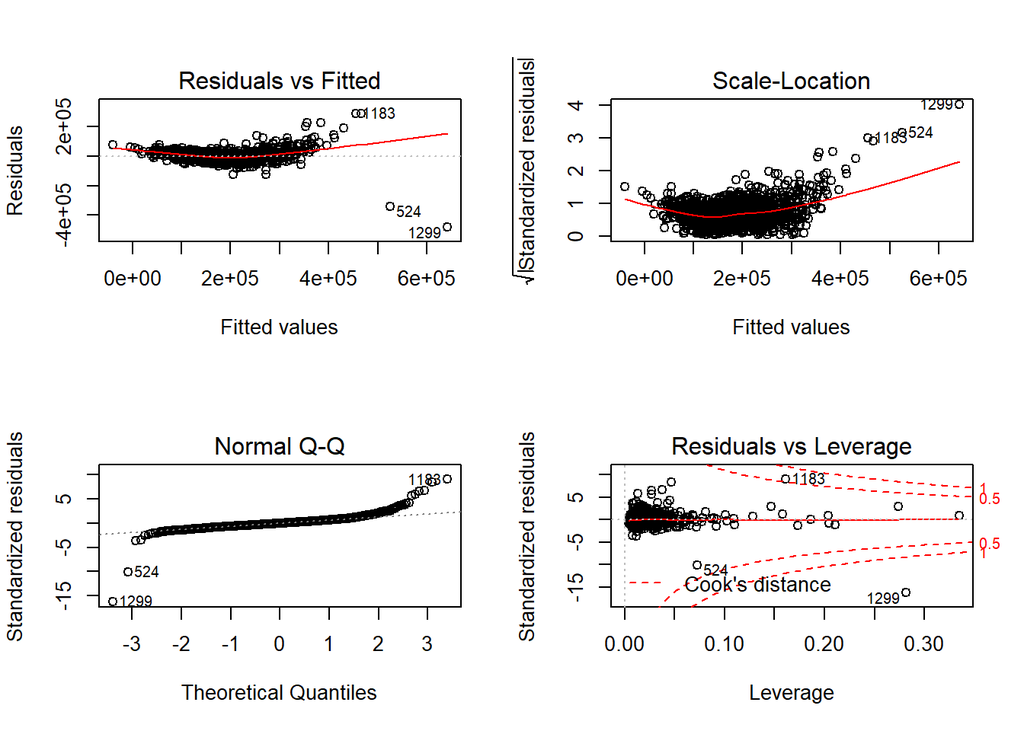

```r
#Graphical Analysis of Second model
layout(matrix(c(1,2,3,4),2,2)) # optional 4 graphs/page
plot(Second_mod)
```

Residual standard error: 35070 on 1433 degrees of freedom

Multiple R-squared: 0.8086, Adjusted R-squared: 0.8051

F-statistic: 232.9 on 26 and 1433 DF, p-value: < 2.2e-16

Discussion for 2nd submission:

The multiple R-squared of 80.86 > 70%. The Adjusted R-squared is 80.51 and higher the better. The F-statistic is 232.9 and higher the better. The p-value < 0.05.

```r
#Starting third variation using variables where p-value < 0.01;

Third_mod = lm(sc.data$SalePrice ~ MSSubClass + LotArea + OverallQual + OverallCond + YearBuilt + YearRemodAdd + BsmtFinSF1 + BsmtUnfSF + TotalBsmtSF + X1stFlrSF + X2ndFlrSF + GrLivArea + BsmtFullBath + FullBath + HalfBath + BedroomAbvGr + KitchenAbvGr + TotRmsAbvGrd + Fireplaces + GarageCars + GarageArea + WoodDeckSF + OpenPorchSF + EnclosedPorch + ScreenPorch + PoolArea, data = sc.data)

summary(Third_mod)
```

```
##
## Call:
## lm(formula = sc.data$SalePrice ~ MSSubClass + LotArea + OverallQual +
##     OverallCond + YearBuilt + YearRemodAdd + BsmtFinSF1 + BsmtUnfSF +
##     TotalBsmtSF + X1stFlrSF + X2ndFlrSF + GrLivArea + BsmtFullBath +
##     FullBath + HalfBath + BedroomAbvGr + KitchenAbvGr + TotRmsAbvGrd +
##     Fireplaces + GarageCars + GarageArea + WoodDeckSF + OpenPorchSF +
##     EnclosedPorch + ScreenPorch + PoolArea, data = sc.data)
##
## Residuals:
##     Min      1Q  Median      3Q     Max
## -481876  -16926   -2280   13326  289614
##
## Coefficients:
##                 Estimate Std. Error t value Pr(>|t|)
## (Intercept)   -1.019e+06  1.356e+05  -7.515 9.97e-14 ***
## MSSubClass    -1.602e+02  2.631e+01  -6.086 1.48e-09 ***
## LotArea        3.995e-01  1.013e-01   3.943 8.43e-05 ***
## OverallQual    1.786e+04  1.190e+03  15.009  < 2e-16 ***
## OverallCond    4.441e+03  1.026e+03   4.329 1.60e-05 ***
## YearBuilt      3.482e+02  6.100e+01   5.708 1.39e-08 ***
## YearRemodAdd   1.354e+02  6.611e+01   2.049 0.040689 *
## BsmtFinSF1     1.477e+01  6.075e+00   2.431 0.015173 *
## BsmtUnfSF      3.231e+00  6.183e+00   0.523 0.601374
## TotalBsmtSF    7.372e+00  7.067e+00   1.043 0.297078
## X1stFlrSF      2.430e+01  2.029e+01   1.198 0.231134
## X2ndFlrSF      2.409e+01  1.997e+01   1.206 0.227834
## GrLivArea      2.653e+01  1.986e+01   1.336 0.181704
## BsmtFullBath   7.935e+03  2.503e+03   3.170 0.001557 **
## FullBath       3.453e+03  2.829e+03   1.221 0.222451
## HalfBath      -1.343e+03  2.681e+03  -0.501 0.616585
## BedroomAbvGr  -1.042e+04  1.698e+03  -6.134 1.10e-09 ***
## KitchenAbvGr  -1.356e+04  5.216e+03  -2.599 0.009437 **
## TotRmsAbvGrd   5.111e+03  1.244e+03   4.109 4.19e-05 ***
## Fireplaces     3.601e+03  1.779e+03   2.024 0.043185 *
## GarageCars     1.087e+04  2.873e+03   3.783 0.000161 ***
## GarageArea     1.000e+00  9.770e+00   0.102 0.918460
## WoodDeckSF     2.604e+01  8.004e+00   3.253 0.001168 **
## OpenPorchSF   -5.109e+00  1.521e+01  -0.336 0.737048
## EnclosedPorch  8.686e+00  1.698e+01   0.512 0.608975
## ScreenPorch    5.677e+01  1.730e+01   3.282 0.001055 **
## PoolArea      -4.133e+01  2.367e+01  -1.746 0.081086 .
## ---
## Signif. codes:  0 '***' 0.001 '**' 0.01 '*' 0.05 '.' 0.1 ' ' 1
##
## Residual standard error: 35070 on 1433 degrees of freedom
## Multiple R-squared:  0.8086, Adjusted R-squared:  0.8051
## F-statistic: 232.9 on 26 and 1433 DF,  p-value: < 2.2e-16
```

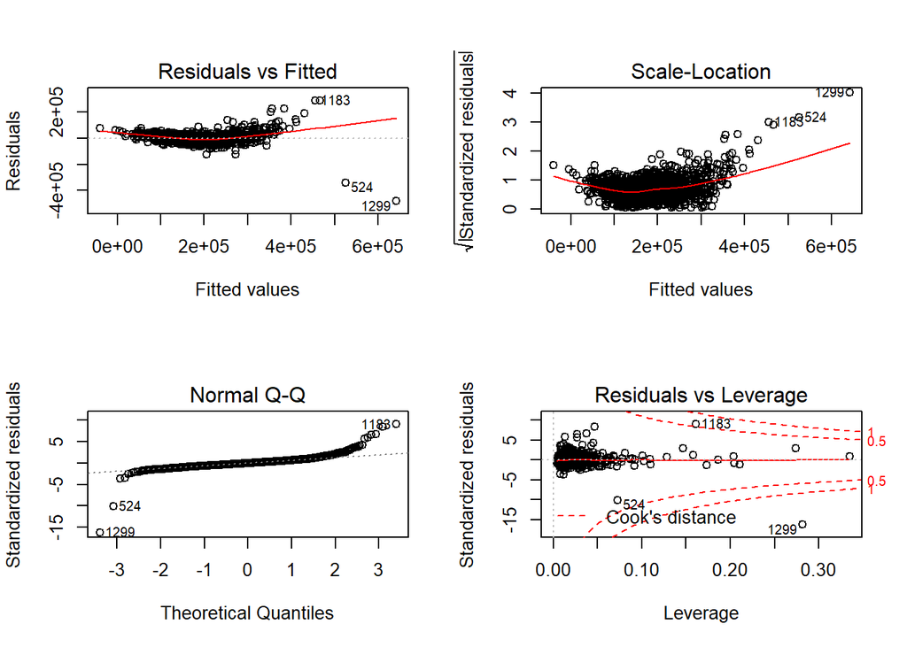

```r
#Graphical Analysis of Third model
layout(matrix(c(1,2,3,4),2,2)) # optional 4 graphs/page
plot(Third_mod)
```

Discussion on 3rd submission:

```r
#For the Fourth variation, we will narrow down the variables based on p-value and correlation test result value >0.50

#https://www.statisticssolutions.com/pearsons-correlation-coefficient/

#Perfect: If the value is near ± 1, then it said to be a perfect correlation: as one variable increases, the other variable tends to also increase (if positive) or decrease (if negative).
#High degree: If the coefficient value lies between ± 0.50 and ± 1, then it is said to be a strong correlation.
#Moderate degree: If the value lies between ± 0.30 and ± 0.49, then it is said to be a medium correlation.
#Low degree: When the value lies below + .29, then it is said to be a small correlation.
#No correlation: When the value is zero.

#Using only variables where the variable's p-value < 0.001 and correlation test value > 0.50

for (i in 2:length(sc.data)) {
  if(is.numeric(sc.data[,i])){
  a <- cor.test(sc.data$SalePrice, sc.data[,i])
  #print(paste(colnames(sc.data)[i], " est:", a$estimate, " p=value:", a$p.value))
  if (a$p.value < 0.001 && a$estimate > 0.50) {
    print(paste(colnames(sc.data)[i], " cor:", a$estimate, " p=value:", a$p.value))
  }
  }
}
```

```
## [1] "OverallQual  cor: 0.790981600583805  p=value: 2.18567526799377e-313"
## [1] "YearBuilt  cor: 0.522897332879497  p=value: 2.99022909901342e-103"
## [1] "YearRemodAdd  cor: 0.507100967111386  p=value: 3.16494824191794e-96"
## [1] "TotalBsmtSF  cor: 0.613580551559196  p=value: 9.48422939149901e-152"
## [1] "X1stFlrSF  cor: 0.605852184691915  p=value: 5.3947106189684e-147"
## [1] "GrLivArea  cor: 0.708624477612652  p=value: 4.51803364677756e-223"
## [1] "FullBath  cor: 0.560663762748446  p=value: 1.23647006675964e-121"
## [1] "TotRmsAbvGrd  cor: 0.533723155582028  p=value: 2.77228093295633e-108"
## [1] "GarageYrBlt  cor: 0.508043287161517  p=value: 1.23482286114448e-96"
## [1] "GarageCars  cor: 0.640409197258352  p=value: 2.49864416717662e-169"
## [1] "GarageArea  cor: 0.623431438918362  p=value: 5.26503816797456e-158"
## [1] "SalePrice  cor: 1  p=value: 0"
```

```r
#Fourth variation using variables where p-value < 0.001 and correlation > 0.50; Rather than add the numeric variables, we will multiply them




Fourth_mod = lm(sc.data$SalePrice ~   OverallQual *  YearBuilt * YearRemodAdd *  TotalBsmtSF * X1stFlrSF *  GrLivArea *  FullBath * TotRmsAbvGrd *  GarageCars * GarageArea , data = sc.data)

summary(Fourth_mod)
```

```
##
## Call:
## lm(formula = sc.data$SalePrice ~ OverallQual * YearBuilt * YearRemodAdd *
##     TotalBsmtSF * X1stFlrSF * GrLivArea * FullBath * TotRmsAbvGrd *
##     GarageCars * GarageArea, data = sc.data)
##
## Residuals:
##     Min      1Q  Median      3Q     Max
## -152690   -5372      -2    5350  139933
##
## Coefficients: (239 not defined because of singularities)
##                                                                                                                  Estimate
## (Intercept)                                                                                                    -2.895e+10
## OverallQual                                                                                                     1.896e+09
## YearBuilt                                                                                                       1.692e+07
## YearRemodAdd                                                                                                    1.420e+07
## TotalBsmtSF                                                                                                     2.031e+06
## X1stFlrSF                                                                                                       1.773e+07
## GrLivArea                                                                                                      -1.774e+06
## FullBath                                                                                                        1.557e+10
## TotRmsAbvGrd                                                                                                    3.301e+09
## GarageCars                                                                                                      1.012e+10
## GarageArea                                                                                                      2.222e+07
## OverallQual:YearBuilt                                                                                          -1.184e+06
## OverallQual:YearRemodAdd                                                                                       -7.190e+05
## YearBuilt:YearRemodAdd                                                                                         -8.334e+03
## OverallQual:TotalBsmtSF                                                                                        -5.150e+05
## YearBuilt:TotalBsmtSF                                                                                          -4.180e+03
## YearRemodAdd:TotalBsmtSF                                                                                       -2.408e+03
## OverallQual:X1stFlrSF                                                                                          -1.400e+06
## YearBuilt:X1stFlrSF                                                                                            -8.332e+03
## YearRemodAdd:X1stFlrSF                                                                                         -6.533e+03
## TotalBsmtSF:X1stFlrSF                                                                                          -2.479e+03
## OverallQual:GrLivArea                                                                                           1.386e+06
## YearBuilt:GrLivArea                                                                                            -3.304e+02
## YearRemodAdd:GrLivArea                                                                                          4.442e+02
## TotalBsmtSF:GrLivArea                                                                                          -9.702e+03
## X1stFlrSF:GrLivArea                                                                                             1.125e+04
## OverallQual:FullBath                                                                                           -8.970e+08
## YearBuilt:FullBath                                                                                             -1.060e+07
```

[output cut: 5087 more lines]

```
## OverallQual:YearBuilt:YearRemodAdd:TotalBsmtSF:X1stFlrSF:GrLivArea:FullBath:GarageCars:GarageArea
## OverallQual:YearBuilt:YearRemodAdd:TotalBsmtSF:X1stFlrSF:GrLivArea:TotRmsAbvGrd:GarageCars:GarageArea
## OverallQual:YearBuilt:YearRemodAdd:TotalBsmtSF:X1stFlrSF:FullBath:TotRmsAbvGrd:GarageCars:GarageArea
## OverallQual:YearBuilt:YearRemodAdd:TotalBsmtSF:GrLivArea:FullBath:TotRmsAbvGrd:GarageCars:GarageArea
## OverallQual:YearBuilt:YearRemodAdd:X1stFlrSF:GrLivArea:FullBath:TotRmsAbvGrd:GarageCars:GarageArea
## OverallQual:YearBuilt:TotalBsmtSF:X1stFlrSF:GrLivArea:FullBath:TotRmsAbvGrd:GarageCars:GarageArea
## OverallQual:YearRemodAdd:TotalBsmtSF:X1stFlrSF:GrLivArea:FullBath:TotRmsAbvGrd:GarageCars:GarageArea
## YearBuilt:YearRemodAdd:TotalBsmtSF:X1stFlrSF:GrLivArea:FullBath:TotRmsAbvGrd:GarageCars:GarageArea
## OverallQual:YearBuilt:YearRemodAdd:TotalBsmtSF:X1stFlrSF:GrLivArea:FullBath:TotRmsAbvGrd:GarageCars:GarageArea
## ---
## Signif. codes:  0 '***' 0.001 '**' 0.01 '*' 0.05 '.' 0.1 ' ' 1
##
## Residual standard error: 21490 on 675 degrees of freedom
## Multiple R-squared:  0.9662, Adjusted R-squared:  0.9268
## F-statistic: 24.57 on 784 and 675 DF,  p-value: < 2.2e-16
```

# Justisfication for the Fourth variation to multiply the variables versus adding

Variables when added produce the following stats

Compared to variables when multipled product the following stats

Multiple R-squared: 0.9662, Adjusted R-squared: 0.9268

F-statistic: 24.57 on 784 and 675 DF, p-value: < 2.2e-16

Discussion on 4th submission:

The multiple R-squared of 96.62 > 70%. The Adjusted R-squared is 92.68 and higher the better. The F-statistic is 24.57 and higher the better. The p-value < 0.05.

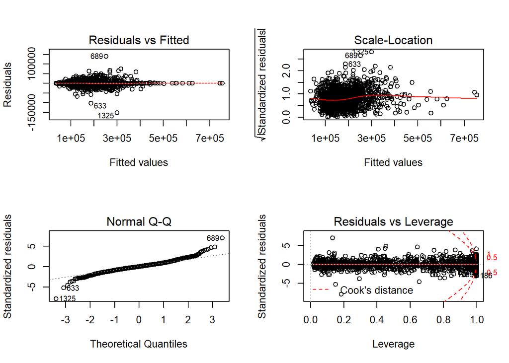

```r
#Graphical Analysis of Fourth model
layout(matrix(c(1,2,3,4),2,2)) # optional 4 graphs/page
plot(Fourth_mod)
```

```r
#For the variation model, we will narrow down the variables based on p-value and correlation test result value > 0.60

#https://www.statisticssolutions.com/pearsons-correlation-coefficient/

#Perfect: If the value is near ± 1, then it said to be a perfect correlation: as one variable increases, the other variable tends to also increase (if positive) or decrease (if negative).
#High degree: If the coefficient value lies between ± 0.50 and ± 1, then it is said to be a strong correlation.
#Moderate degree: If the value lies between ± 0.30 and ± 0.49, then it is said to be a medium correlation.
#Low degree: When the value lies below + .29, then it is said to be a small correlation.
#No correlation: When the value is zero.

#Using only variables where the variable's p-value < 0.001 and correlation test value > 0.60

for (i in 2:length(sc.data)) {
  if(is.numeric(sc.data[,i])){
  a <- cor.test(sc.data$SalePrice, sc.data[,i])
  #print(paste(colnames(sc.data)[i], " est:", a$estimate, " p=value:", a$p.value))
  if (a$p.value < 0.001 && a$estimate > 0.60) {
    print(paste(colnames(sc.data)[i], " cor:", a$estimate, " p=value:", a$p.value))
  }
  }
}
```

```
## [1] "OverallQual  cor: 0.790981600583805  p=value: 2.18567526799377e-313"
## [1] "TotalBsmtSF  cor: 0.613580551559196  p=value: 9.48422939149901e-152"
## [1] "X1stFlrSF  cor: 0.605852184691915  p=value: 5.3947106189684e-147"
## [1] "GrLivArea  cor: 0.708624477612652  p=value: 4.51803364677756e-223"
## [1] "GarageCars  cor: 0.640409197258352  p=value: 2.49864416717662e-169"
## [1] "GarageArea  cor: 0.623431438918362  p=value: 5.26503816797456e-158"
## [1] "SalePrice  cor: 1  p=value: 0"
```

```r
#Fifth variation using variables where p-value < 0.001 and correlation > 0.60; Rather than add the numeric variables, we will multiply them




Fifth_mod = lm(sc.data$SalePrice ~   OverallQual *   TotalBsmtSF * X1stFlrSF *  GrLivArea *  GarageCars * GarageArea , data = sc.data)

summary(Fifth_mod)
```

```
##
## Call:
## lm(formula = sc.data$SalePrice ~ OverallQual * TotalBsmtSF *
##     X1stFlrSF * GrLivArea * GarageCars * GarageArea, data = sc.data)
##
## Residuals:
##     Min      1Q  Median      3Q     Max
## -150828  -13623     129   13992  159904
##
## Coefficients:
##                                                                     Estimate
## (Intercept)                                                       -5.919e+04
## OverallQual                                                        1.230e+04
## TotalBsmtSF                                                       -2.912e+02
## X1stFlrSF                                                          4.627e+01
## GrLivArea                                                          2.485e+02
## GarageCars                                                         2.666e+05
## GarageArea                                                         4.536e+02
## OverallQual:TotalBsmtSF                                            6.825e+01
## OverallQual:X1stFlrSF                                              5.816e+00
## TotalBsmtSF:X1stFlrSF                                              3.480e-01
## OverallQual:GrLivArea                                             -3.995e+01
## TotalBsmtSF:GrLivArea                                              5.422e-02
## X1stFlrSF:GrLivArea                                               -1.847e-01
## OverallQual:GarageCars                                            -1.128e+04
## TotalBsmtSF:GarageCars                                            -2.054e+02
## X1stFlrSF:GarageCars                                               8.372e+00
## GrLivArea:GarageCars                                              -4.306e+02
## OverallQual:GarageArea                                            -2.409e+02
## TotalBsmtSF:GarageArea                                             6.128e-01
## X1stFlrSF:GarageArea                                               6.614e-02
## GrLivArea:GarageArea                                              -3.117e-01
## GarageCars:GarageArea                                             -9.487e+02
## OverallQual:TotalBsmtSF:X1stFlrSF                                 -7.585e-02
## OverallQual:TotalBsmtSF:GrLivArea                                 -1.339e-02
## OverallQual:X1stFlrSF:GrLivArea                                    2.965e-02
## TotalBsmtSF:X1stFlrSF:GrLivArea                                   -9.755e-05
## OverallQual:TotalBsmtSF:GarageCars                                -1.308e+01
## OverallQual:X1stFlrSF:GarageCars                                  -3.731e+01
## TotalBsmtSF:X1stFlrSF:GarageCars                                  -1.684e-02
```

[output cut: 286 more lines]

```
## TotalBsmtSF:GrLivArea:GarageCars:GarageArea                       **
## X1stFlrSF:GrLivArea:GarageCars:GarageArea
## OverallQual:TotalBsmtSF:X1stFlrSF:GrLivArea:GarageCars
## OverallQual:TotalBsmtSF:X1stFlrSF:GrLivArea:GarageArea
## OverallQual:TotalBsmtSF:X1stFlrSF:GarageCars:GarageArea
## OverallQual:TotalBsmtSF:GrLivArea:GarageCars:GarageArea           **
## OverallQual:X1stFlrSF:GrLivArea:GarageCars:GarageArea             *
## TotalBsmtSF:X1stFlrSF:GrLivArea:GarageCars:GarageArea
## OverallQual:TotalBsmtSF:X1stFlrSF:GrLivArea:GarageCars:GarageArea
## ---
## Signif. codes:  0 '***' 0.001 '**' 0.01 '*' 0.05 '.' 0.1 ' ' 1
##
## Residual standard error: 27840 on 1396 degrees of freedom
## Multiple R-squared:  0.8825, Adjusted R-squared:  0.8772
## F-statistic: 166.5 on 63 and 1396 DF,  p-value: < 2.2e-16
```

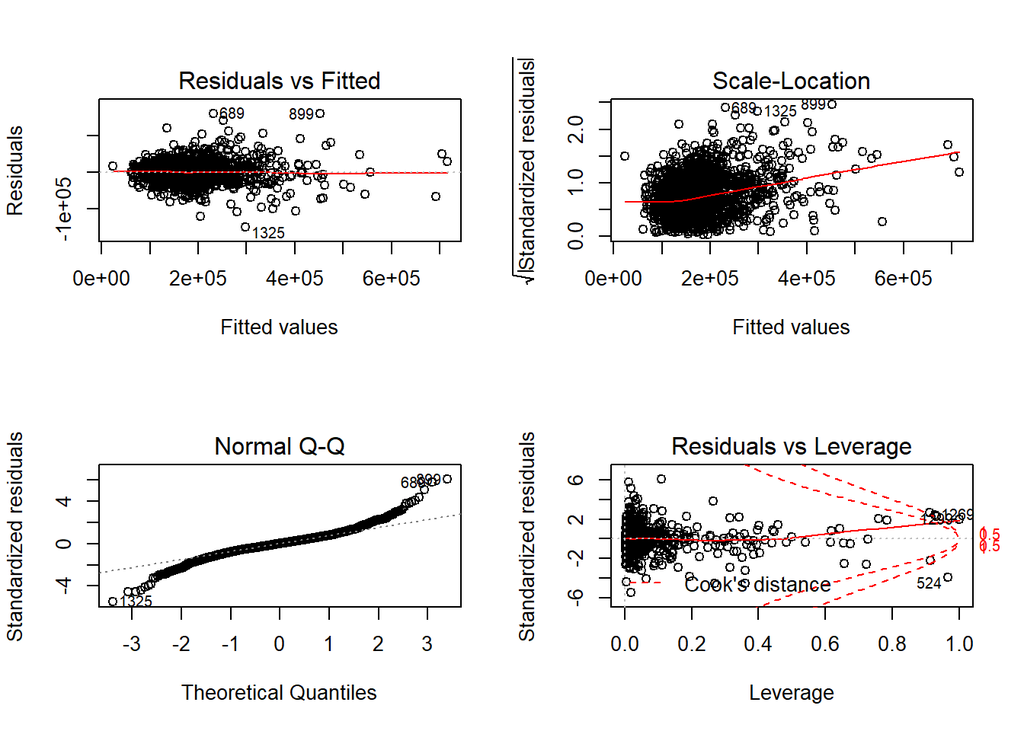

```r
#Graphical Analysis of Fourth model
layout(matrix(c(1,2,3,4),2,2)) # optional 4 graphs/page
plot(Fifth_mod)
```

Residual standard error: 27840 on 1396 degrees of freedom

Multiple R-squared: 0.8825, Adjusted R-squared: 0.8772

F-statistic: 166.5 on 63 and 1396 DF, p-value: < 2.2e-16

Discussion on 5th submission:

The multiple R-squared of 88.25 > 70%. The Adjusted R-squared is 87.72 and higher the better. The F-statistic is 166.5 and higher the better. The p-value < 0.05.

# Compiled submission results:

First iteration: (All variables)

Second iteration: (#Second variation using variables where p-value < 0.05)

Fourth iteration: (Fourth variation using variables where p-value < 0.001 and correlation > 0.50; Rather than add the numeric variables, we will multiply them)

Fifth iteration: (Fifth variation using variables where p-value < 0.001 and correlation > 0.60; Rather than add the numeric variables, we will multiply them)

Final iteration

```r
#For the Sixth variation, we will narrow down the variables based on p-value and correlation test result value > 0.70

#https://www.statisticssolutions.com/pearsons-correlation-coefficient/

#Perfect: If the value is near ± 1, then it said to be a perfect correlation: as one variable increases, the other variable tends to also increase (if positive) or decrease (if negative).
#High degree: If the coefficient value lies between ± 0.50 and ± 1, then it is said to be a strong correlation.
#Moderate degree: If the value lies between ± 0.30 and ± 0.49, then it is said to be a medium correlation.
#Low degree: When the value lies below + .29, then it is said to be a small correlation.
#No correlation: When the value is zero.

#Using only variables where the variable's p-value < 0.001 and correlation test value > 0.70

for (i in 2:length(sc.data)) {
  if(is.numeric(sc.data[,i])){
  a <- cor.test(sc.data$SalePrice, sc.data[,i])
  #print(paste(colnames(sc.data)[i], " est:", a$estimate, " p=value:", a$p.value))
  if (a$p.value < 0.001 && a$estimate > 0.70) {
    print(paste(colnames(sc.data)[i], " cor:", a$estimate, " p=value:", a$p.value))
  }
  }
}
```

```
## [1] "OverallQual  cor: 0.790981600583805  p=value: 2.18567526799377e-313"
## [1] "GrLivArea  cor: 0.708624477612652  p=value: 4.51803364677756e-223"
## [1] "SalePrice  cor: 1  p=value: 0"
```

```r
#Sixth variation using variables where p-value < 0.001 and correlation > 0.70; Rather than add the numeric variables, we will multiply them and make one of them quadratic
set.seed(100)  # setting seed to reproduce results of random sampling
trainingRowIndex <- sample(1:nrow(sc.data), 0.8*nrow(sc.data))  # row indices for training data
trainingData <- sc.data[trainingRowIndex, ]  # model training data
testData  <- sc.data[-trainingRowIndex, ]    # test data

Sixth_mod <- lm((sc.data$SalePrice) ~ OverallQual * GrLivArea   , data = sc.data)

summary(Sixth_mod)
```

```
##
## Call:
## lm(formula = (sc.data$SalePrice) ~ OverallQual * GrLivArea, data = sc.data)
##
## Residuals:
##     Min      1Q  Median      3Q     Max
## -527522  -20527      30   17832  271107
##
## Coefficients:
##                        Estimate Std. Error t value Pr(>|t|)
## (Intercept)           10031.529  12099.368   0.829  0.40719
## OverallQual           15409.364   1948.165   7.910 5.06e-15 ***
## GrLivArea               -23.428      8.103  -2.891  0.00389 **
## OverallQual:GrLivArea    11.620      1.128  10.305  < 2e-16 ***
## ---
## Signif. codes:  0 '***' 0.001 '**' 0.01 '*' 0.05 '.' 0.1 ' ' 1
##
## Residual standard error: 41050 on 1456 degrees of freedom
## Multiple R-squared:  0.7336, Adjusted R-squared:  0.7331
## F-statistic:  1337 on 3 and 1456 DF,  p-value: < 2.2e-16
```

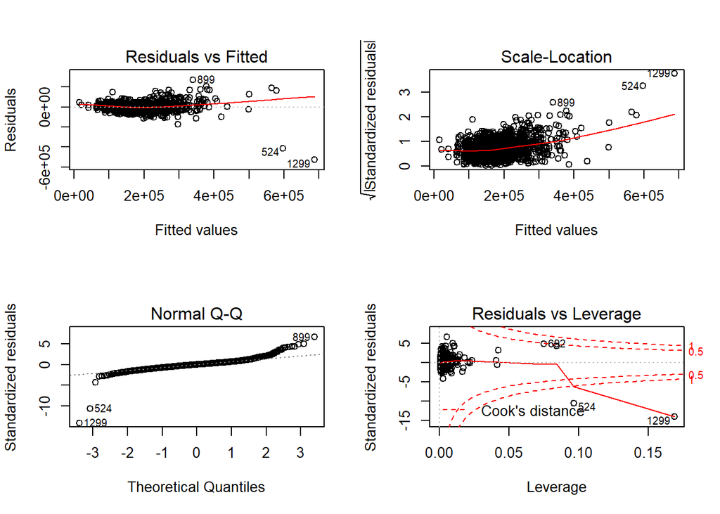

```r
#Graphical Analysis of Fourth model
layout(matrix(c(1,2,3,4),2,2)) # optional 4 graphs/page
plot(Sixth_mod)
```

Residual standard error: 41050 on 1456 degrees of freedom

Multiple R-squared: 0.7336, Adjusted R-squared: 0.7331

F-statistic: 1337 on 3 and 1456 DF, p-value: < 2.2e-16

Discussion on 6th submission:

The multiple R-squared of 73.36 > 70%. The Adjusted R-squared is 73.31 and higher the better. The F-statistic is 1337 and higher the better. The p-value < 0.05.

```r
kaggle_test <- read.csv("c:\\Users\\ajaya\\Documents\\AJAY\\Computational Math\\Final\\test.csv")

SalePrice <- predict(Sixth_mod, newdata = kaggle_test, type="response")

kagglefile <- cbind.data.frame(kaggle_test$Id, SalePrice)


write.csv(kagglefile,'C:\\Users\\ajaya\\Documents\\AJAY\\Computational Math\\Final\\ajaj6.csv',row.names = F)
```

# Result from Final variation ()

# Kaggle score: 0.21936 User name: ajayarora35